# IODS course project

Salla Veijonaho

# Introduction to Open Data Science - Course Project

# 26.10.2020

# **Exercise 1**

**Feelings about the course**

*I heard about this course from my friends. They took it last year and they really liked it. I’ve bee thinking that I should learn some basics of R for a long time now and now I had the opportunity to attend to this course*.

**My diary:** [Click here](https://sallavei.github.io/IODS-project)

```r
date()
```

```
## [1] "Fri Dec 04 16:08:43 2020"
```

# 2.11.2020

# **Exercise 2: Regression and model validation**

####**Description of analysed data**

The aim of this study was to set light on the relationship between learning approaches and students’ achievements in an introductory statistics course in Finland.

The data set (N = 166) used in this report consisted of 7 variables: Gender, Age, attitude, Deep approach, Surface approach, Strategic approach and total points. The participants were 17-55-years-olds (mean = 25.5) and 66 % of them were Female.

Read more about the used scales and variables from [here](https://www.mv.helsinki.fi/home/kvehkala/JYTmooc/JYTOPKYS2-meta.txt)

R script for graphical overview of the data:

```r
library()
analysisdata <- read.table("http://s3.amazonaws.com/assets.datacamp.com/production/course_2218/datasets/learning2014.txt", sep=",", header=TRUE)

#Description of data set
library(psych)

describe(analysisdata[-1])
```

```
##          vars   n  mean   sd median trimmed  mad   min   max range  skew
## age         1 166 25.51 7.77  22.00   23.99 2.97 17.00 55.00 38.00  1.89
## attitude    2 166  3.14 0.73   3.20    3.15 0.74  1.40  5.00  3.60 -0.08
## deep        3 166  3.68 0.55   3.67    3.70 0.62  1.58  4.92  3.33 -0.50
## stra        4 166  3.12 0.77   3.19    3.14 0.83  1.25  5.00  3.75 -0.11
## surf        5 166  2.79 0.53   2.83    2.78 0.62  1.58  4.33  2.75  0.14
## points      6 166 22.72 5.89  23.00   23.08 5.93  7.00 33.00 26.00 -0.40
##          kurtosis   se
## age          3.24 0.60
## attitude    -0.48 0.06
## deep         0.66 0.04
## stra        -0.45 0.06
## surf        -0.27 0.04
## points      -0.26 0.46
```

##### **Here’s a little glossary to help understand the short terms used in tables:**

**deep** = Deep approach

**surf** = Surface approach

**stra** = Strategic approach

**points** = total points

**F** = Female

**M** = Male

See the means, standard deviations, medians, minimum and maxim values from the table above. The table also shows skewness and kuriosis which tell us the normality of the variables. All the sum variables were normally distributed.

##### **Bellow you can find information about gender:**

```r
table(analysisdata$gender)
```

```
##
##   F   M
## 110  56
```

#### **A Plot Matrix**

Find bellow a plot matrix that includes all the variables. As you can see from the matrix, there are great significant correlation between surface approach & deep approach and attitude & points.

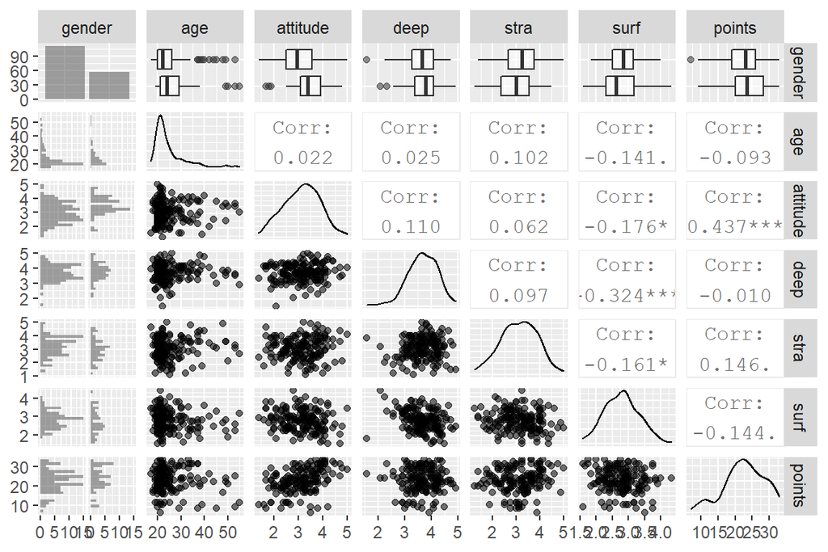

```r
# creating a plot matrix out of all the variables.
library(GGally)
library(ggplot2)

p <- ggpairs(analysisdata, mapping = aes(alpha = 0.3), lower = list(combo = wrap("facethist", bins = 20)))

p
```

#### Creating a regression model with explanatory variables

I chose surf, deep and attitude as the predicted variables for this exercise. Total points were my dependent variable.

Bellow you can find model fit indexes.

```r
# creating a regression model with multiple explanatory variables
my_model <- lm(points ~ attitude + deep + surf, data = analysisdata)

# printing out a summary of the model
summary(my_model)
```

```
##
## Call:
## lm(formula = points ~ attitude + deep + surf, data = analysisdata)
##
## Residuals:
##      Min       1Q   Median       3Q      Max
## -16.9168  -3.1487   0.3667   3.8326  11.3519
##
## Coefficients:
##             Estimate Std. Error t value Pr(>|t|)
## (Intercept)  18.3551     4.7124   3.895 0.000143 ***
## attitude      3.4661     0.5766   6.011 1.18e-08 ***
## deep         -0.9485     0.7903  -1.200 0.231815
## surf         -1.0911     0.8360  -1.305 0.193669
## ---
## Signif. codes:  0 '***' 0.001 '**' 0.01 '*' 0.05 '.' 0.1 ' ' 1
##
## Residual standard error: 5.313 on 162 degrees of freedom
## Multiple R-squared:  0.2024, Adjusted R-squared:  0.1876
## F-statistic:  13.7 on 3 and 162 DF,  p-value: 5.217e-08
```

#### **Interpretation of the model fit**

```r
# creating a regression model
my_model2 <- lm(points ~ attitude, data = analysisdata)

# printing out a summary of the model
summary(my_model2)
```

```
##
## Call:
## lm(formula = points ~ attitude, data = analysisdata)
##
## Residuals:
##      Min       1Q   Median       3Q      Max
## -16.9763  -3.2119   0.4339   4.1534  10.6645
##
## Coefficients:
##             Estimate Std. Error t value Pr(>|t|)
## (Intercept)  11.6372     1.8303   6.358 1.95e-09 ***
## attitude      3.5255     0.5674   6.214 4.12e-09 ***
## ---
## Signif. codes:  0 '***' 0.001 '**' 0.01 '*' 0.05 '.' 0.1 ' ' 1
##
## Residual standard error: 5.32 on 164 degrees of freedom
## Multiple R-squared:  0.1906, Adjusted R-squared:  0.1856
## F-statistic: 38.61 on 1 and 164 DF,  p-value: 4.119e-09
```

#### **Results of the regression analysis**

Seems like only attitude predicts overall exam points. Good attitude predicts high exam points.The multiple of R squared of the model shows that 19% of the variation is points is explained by the attitude.

#### **Residuals vs Fitted values, Normal QQ-plot and Residuals vs Leverage**

As you can see bellow *Residual vs. Fitter points* spread randomly. *Normal Q-Q plot points* fits quite well to the line which indicates that the model is normally distributed. There are no outliners standing out in *Residuals vs. Leverage plot*.

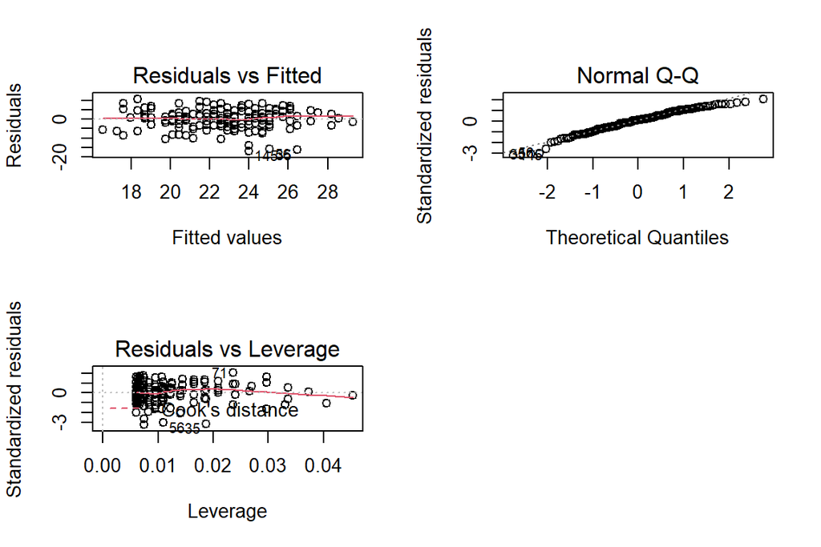

```r
par(mfrow = c(2,2))
plot(my_model2, which = c(1, 2, 5))
```

# 09.11.2020

# **Exercise 3: Logistic regression**

**Description of the analysed data**

The data used in this exercise was collected from two secondary education schools in Portugal. The data includes information about weekly alcohol use, grades (in Mathematics and Portuguese), demographic, social and school related features.

Read more about the used scales and variables from [here](https://archive.ics.uci.edu/ml/datasets/Student+Performance)

Find bellow the descriptives of variables in the data set

```r
#Open packages
library(tidyverse)
library(tidyr)
library(psych)
library(dplyr)
library(ggplot2)
library(GGally)
library(patchwork)
library(openxlsx)

#Read the data
alc_data <- read.table("http://s3.amazonaws.com/assets.datacamp.com/production/course_2218/datasets/alc.txt", sep=",", header=TRUE)

#Checking the data
summary(alc_data)
```

```r
describe(alc_data)
```

```
##             vars   n  mean   sd median trimmed  mad min  max range  skew
## school*        1 382  1.10 0.31    1.0    1.01 0.00   1    2     1  2.57
## sex*           2 382  1.48 0.50    1.0    1.48 0.00   1    2     1  0.07
## age            3 382 16.59 1.17   17.0   16.55 1.48  15   22     7  0.40
## address*       4 382  1.79 0.41    2.0    1.86 0.00   1    2     1 -1.40
## famsize*       5 382  1.27 0.45    1.0    1.22 0.00   1    2     1  1.02
## Pstatus*       6 382  1.90 0.30    2.0    2.00 0.00   1    2     1 -2.67
## Medu           7 382  2.81 1.09    3.0    2.89 1.48   0    4     4 -0.38
## Fedu           8 382  2.57 1.10    3.0    2.59 1.48   0    4     4 -0.09
## Mjob*          9 382  3.21 1.23    3.0    3.26 1.48   1    5     4 -0.33
## Fjob*         10 382  3.31 0.85    3.0    3.33 0.00   1    5     4 -0.26
## reason*       11 382  2.24 1.20    2.0    2.17 1.48   1    4     3  0.44
## nursery*      12 382  1.81 0.39    2.0    1.89 0.00   1    2     1 -1.59
## internet*     13 382  1.85 0.36    2.0    1.93 0.00   1    2     1 -1.93
## guardian*     14 382  1.80 0.49    2.0    1.83 0.00   1    3     2 -0.39
## traveltime    15 382  1.44 0.70    1.0    1.31 0.00   1    4     3  1.63
## studytime     16 382  2.03 0.85    2.0    1.95 1.48   1    4     3  0.64
## failures      17 382  0.29 0.73    0.0    0.09 0.00   0    3     3  2.69
## schoolsup*    18 382  1.13 0.34    1.0    1.04 0.00   1    2     1  2.15
## famsup*       19 382  1.62 0.49    2.0    1.65 0.00   1    2     1 -0.51
## paid*         20 382  1.46 0.50    1.0    1.45 0.00   1    2     1  0.15
## activities*   21 382  1.53 0.50    2.0    1.53 0.00   1    2     1 -0.10
## higher*       22 382  1.95 0.21    2.0    2.00 0.00   1    2     1 -4.26
## romantic*     23 382  1.32 0.47    1.0    1.27 0.00   1    2     1  0.78
## famrel        24 382  3.94 0.92    4.0    4.04 1.48   1    5     4 -0.96
## freetime      25 382  3.22 0.99    3.0    3.22 1.48   1    5     4 -0.15
## goout         26 382  3.11 1.13    3.0    3.09 1.48   1    5     4  0.10
## Dalc          27 382  1.47 0.89    1.0    1.26 0.00   1    5     4  2.22
## Walc          28 382  2.28 1.28    2.0    2.14 1.48   1    5     4  0.63
## health        29 382  3.58 1.40    4.0    3.72 1.48   1    5     4 -0.52
## absences      30 382  5.32 7.63    3.0    3.93 4.45   0   75    75  4.01
## G1            31 382 10.86 3.35   10.5   10.75 3.71   3   19    16  0.27
## G2            32 382 10.71 3.83   11.0   10.83 2.97   0   19    19 -0.40
## G3            33 382 10.39 4.69   11.0   10.81 4.45   0   20    20 -0.70
## alc_use       34 382  1.88 0.99    1.5    1.72 0.74   1    5     4  1.20
## high_use      35 382   NaN   NA     NA     NaN   NA Inf -Inf  -Inf    NA
##             kurtosis   se
## school*         4.63 0.02
## sex*           -2.00 0.03
## age             0.06 0.06
```

[output cut: 17 more lines]

```
## activities*    -1.99 0.03
## higher*        16.17 0.01
## romantic*      -1.39 0.02
## famrel          1.04 0.05
## freetime       -0.29 0.05
## goout          -0.82 0.06
## Dalc            4.92 0.05
## Walc           -0.77 0.07
## health         -1.02 0.07
## absences       26.29 0.39
## G1             -0.71 0.17
## G2              0.47 0.20
## G3              0.24 0.24
## alc_use         0.97 0.05
## high_use          NA   NA
```

##### **Exploratory analysis**

I chose following variables to do exploratory analysis: current health status (health), number of past class failures (failures), going out with friends (goout) and quality of family relationships (famrel).

My hypothesis (based on my personal speculations):

H1. Good health status is negatively related to high alcohol consumption.

H2. Number of past class failures is positively related to high alcohol consumption.

H3. Going out with friends increases the risk for high alcohol consumption.

H4. Higher quality of family relationships reduce the risk for high alcohol consumption.

##### **Exploring the the distributions of the chosen variables and their relationships with alcohol consumption**

###### *Health status*

Despite of what was assumed above (H1), There are not big differences in health status between the high alcohol users and the others when we look at the boxplots. The Chi-squared test also indicates that there is no statistically significant relationship between these two variables (p > .05).

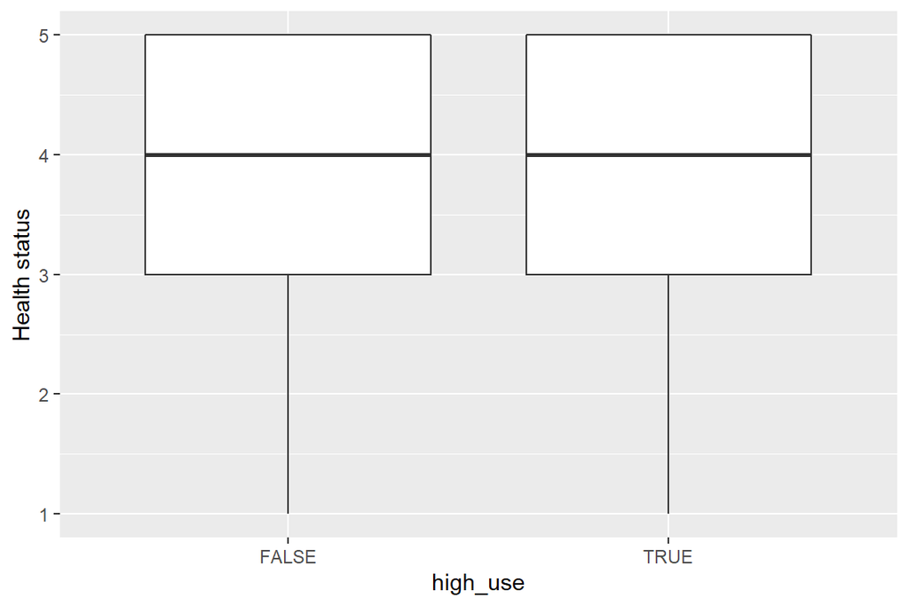

```r
g1 <- ggplot(alc_data, aes(x = high_use, y = health))
g1 + geom_boxplot() + ylab("Health status")
```

```r
prop.table(table(alc_data$health, alc_data$high_use))
```

```
##
##          FALSE       TRUE
##   1 0.09162304 0.02879581
##   2 0.07591623 0.03664921
##   3 0.16492147 0.05235602
##   4 0.12303665 0.04450262
##   5 0.25130890 0.13089005
```

```r
chisq.test(alc_data$health,alc_data$high_use)
```

```
##
##  Pearson's Chi-squared test
##
## data:  alc_data$health and alc_data$high_use
## X-squared = 3.9042, df = 4, p-value = 0.4191
```

##### *Class failures*

As assumed in hypothesis (H2), the high alcohol users have more past class failures when we look at the boxplots.The Chi-squared test also indicates that the relationship is statically significant (p < .05).

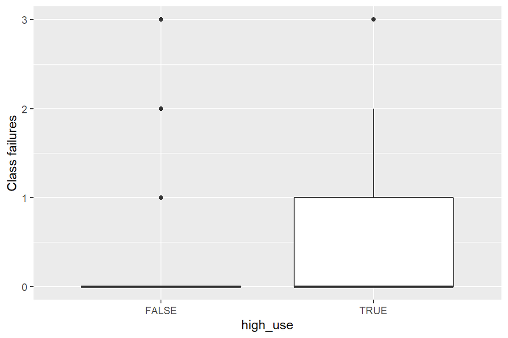

```r
g1 <- ggplot(alc_data, aes(x = high_use, y = failures))
g1 + geom_boxplot() + ylab("Class failures")
```

```r
prop.table(table(alc_data$failures, alc_data$high_use))
```

```
##
##          FALSE       TRUE
##   0 0.61256545 0.21465969
##   1 0.05759162 0.04188482
##   2 0.01308901 0.01570681
##   3 0.02356021 0.02094241
```

```r
chisq.test(alc_data$failures,alc_data$high_use)
```

```
##
##  Pearson's Chi-squared test
##
## data:  alc_data$failures and alc_data$high_use
## X-squared = 10.689, df = 3, p-value = 0.01353
```

##### *Going out with friends*

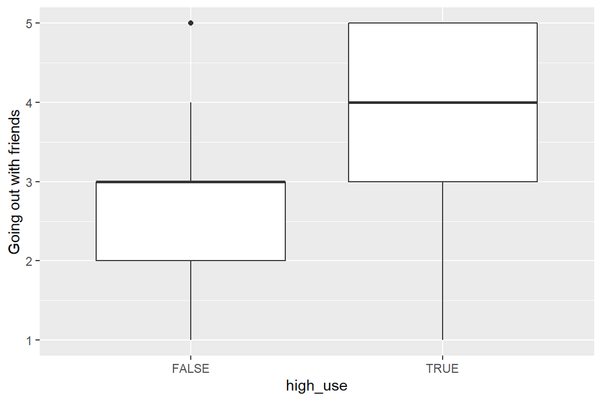

```r
g1 <- ggplot(alc_data, aes(x = high_use, y = goout))
g1 + geom_boxplot() + ylab("Going out with friends")
```

```r
prop.table(table(alc_data$goout, alc_data$high_use))
```

```
##
##           FALSE        TRUE
##   1 0.054973822 0.007853403
##   2 0.219895288 0.039267016
##   3 0.261780105 0.060209424
##   4 0.112565445 0.102094241
##   5 0.057591623 0.083769634
```

```r
chisq.test(alc_data$goout,alc_data$high_use)
```

```
##
##  Pearson's Chi-squared test
##
## data:  alc_data$goout and alc_data$high_use
## X-squared = 56.085, df = 4, p-value = 1.924e-11
```

##### *Family relationships*

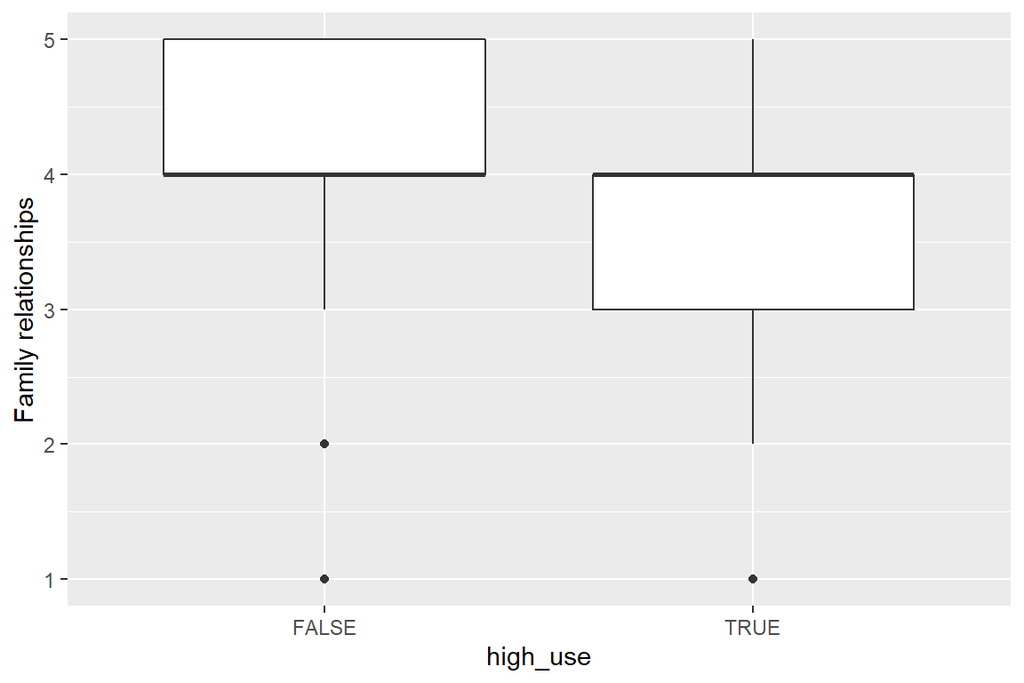

```r
g1 <- ggplot(alc_data, aes(x = high_use, y = famrel))
g1 + geom_boxplot() + ylab("Family relationships")
```

```r
prop.table(table(alc_data$famrel, alc_data$high_use))
```

```
##
##           FALSE        TRUE
##   1 0.018324607 0.005235602
##   2 0.023560209 0.023560209
##   3 0.104712042 0.068062827
##   4 0.342931937 0.136125654
##   5 0.217277487 0.060209424
```

```r
chisq.test(alc_data$famrel,alc_data$high_use)
```

```
##
##  Pearson's Chi-squared test
##
## data:  alc_data$famrel and alc_data$high_use
## X-squared = 10.209, df = 4, p-value = 0.03705
```

Based on the model bellow, only going out with friends and family relationships are significant predictors of high alcohol consumption. Hypothesis H1 and H2 are rejected. Health and failures variables will be moved from the model for further analysis.

```r
model_1 <-
  glm(high_use ~
        health + failures + goout + famrel,
      data=alc_data)
summary(model_1)
```

```
##
## Call:
## glm(formula = high_use ~ health + failures + goout + famrel,
##     data = alc_data)
##
## Deviance Residuals:
##     Min       1Q   Median       3Q      Max
## -0.6982  -0.2948  -0.1512   0.3664   0.9922
##
## Coefficients:
##             Estimate Std. Error t value Pr(>|t|)
## (Intercept)  0.03741    0.11781   0.318  0.75099
## health       0.02741    0.01547   1.772  0.07715 .
## failures     0.05708    0.02986   1.911  0.05671 .
## goout        0.14350    0.01920   7.475 5.46e-13 ***
## famrel      -0.07755    0.02355  -3.293  0.00109 **
## ---
## Signif. codes:  0 '***' 0.001 '**' 0.01 '*' 0.05 '.' 0.1 ' ' 1
##
## (Dispersion parameter for gaussian family taken to be 0.1752756)
##
##     Null deviance: 79.162  on 381  degrees of freedom
## Residual deviance: 66.079  on 377  degrees of freedom
## AIC: 425.82
##
## Number of Fisher Scoring iterations: 2
```

```r
model_2 <-
  glm(high_use ~
        goout + famrel,
      data=alc_data)
summary(model_2)
```

```
##
## Call:
## glm(formula = high_use ~ goout + famrel, data = alc_data)
##
## Deviance Residuals:
##     Min       1Q   Median       3Q      Max
## -0.6432  -0.2720  -0.1633   0.4337   1.0223
##
## Coefficients:
##             Estimate Std. Error t value Pr(>|t|)
## (Intercept)  0.13843    0.10827   1.279  0.20184
## goout        0.14713    0.01915   7.685 1.33e-13 ***
## famrel      -0.07696    0.02352  -3.273  0.00116 **
## ---
## Signif. codes:  0 '***' 0.001 '**' 0.01 '*' 0.05 '.' 0.1 ' ' 1
##
## (Dispersion parameter for gaussian family taken to be 0.1778195)
##
##     Null deviance: 79.162  on 381  degrees of freedom
## Residual deviance: 67.394  on 379  degrees of freedom
## AIC: 429.35
##
## Number of Fisher Scoring iterations: 2
```

```r
model_3 <-
  glm(high_use ~
        famrel + goout,
      data=alc_data)

OR <- exp(coef(model_3))
CI <- exp(confint(model_3))
cbind(OR,CI)
```

```
##                    OR     2.5 %    97.5 %
## (Intercept) 1.1484690 0.9288790 1.4199709
## famrel      0.9259302 0.8842233 0.9696043
## goout       1.1585063 1.1158377 1.2028064
```

**Cross tabulation**

As seen bellow, the number of inaccurately classified individuals is around 27%. The model estimates that 11% would be high alcohol users.

```r
probs <- predict(model_2, type = "response")
alc_data <- mutate(alc_data, probability = probs)

alc_data <- mutate(alc_data, predicted_high=probability> 0.5)

table(high_use = alc_data$high_use, prediction = alc_data$predicted_high) %>% prop.table() %>% addmargins()
```

```
##         prediction
## high_use      FALSE       TRUE        Sum
##    FALSE 0.66492147 0.04188482 0.70680628
##    TRUE  0.22513089 0.06806283 0.29319372
##    Sum   0.89005236 0.10994764 1.00000000
```

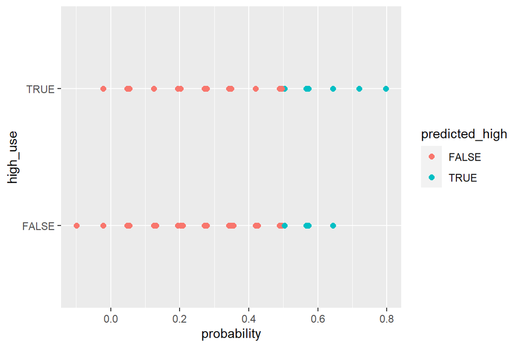

```r
ggplot(alc_data, aes(x = probability, y = high_use, col=predicted_high)) +
 geom_point(size=2)
```

```r
loss_func <- function(class, prob) {
 n_wrong <- abs(class - prob) > 0.5
 mean(n_wrong)
}

loss_func(class = alc_data$high_use, prob = alc_data$probability)
```

```
## [1] 0.2670157
```

# 16.11.2020

# **Exercise 4: Clustering and classification**

*!!Note that I’ve decided to hide my codes because the report looks much clearer without them. Whenever you need to see the codes I’ve written, please click the “code”-boxes on the right.!!*

**Description of the analysed data**

The data used in this exercise includes information of housing values in Suburbs of Boston. The Boston data frame has 506 rows and 14 columns.

Read more about the used scales and variables from [here](https://stat.ethz.ch/R-manual/R-devel/library/MASS/html/Boston.html)

I’ll mostly focus on the crime rate in the city in this exercise.

Find bellow the descriptions of variables in the data set

```r
#Open packages
library(MASS)
library(psych)
library(tidyverse)
library(corrplot)
library(GGally)

#Read the data
data("Boston")

#Checking the data
str(Boston)
```

```r
describe(Boston)
```

```
##         vars   n   mean     sd median trimmed    mad    min    max  range  skew
## crim       1 506   3.61   8.60   0.26    1.68   0.33   0.01  88.98  88.97  5.19
## zn         2 506  11.36  23.32   0.00    5.08   0.00   0.00 100.00 100.00  2.21
## indus      3 506  11.14   6.86   9.69   10.93   9.37   0.46  27.74  27.28  0.29
## chas       4 506   0.07   0.25   0.00    0.00   0.00   0.00   1.00   1.00  3.39
## nox        5 506   0.55   0.12   0.54    0.55   0.13   0.38   0.87   0.49  0.72
## rm         6 506   6.28   0.70   6.21    6.25   0.51   3.56   8.78   5.22  0.40
## age        7 506  68.57  28.15  77.50   71.20  28.98   2.90 100.00  97.10 -0.60
## dis        8 506   3.80   2.11   3.21    3.54   1.91   1.13  12.13  11.00  1.01
## rad        9 506   9.55   8.71   5.00    8.73   2.97   1.00  24.00  23.00  1.00
## tax       10 506 408.24 168.54 330.00  400.04 108.23 187.00 711.00 524.00  0.67
## ptratio   11 506  18.46   2.16  19.05   18.66   1.70  12.60  22.00   9.40 -0.80
## black     12 506 356.67  91.29 391.44  383.17   8.09   0.32 396.90 396.58 -2.87
## lstat     13 506  12.65   7.14  11.36   11.90   7.11   1.73  37.97  36.24  0.90
## medv      14 506  22.53   9.20  21.20   21.56   5.93   5.00  50.00  45.00  1.10
##         kurtosis   se
## crim       36.60 0.38
## zn          3.95 1.04
## indus      -1.24 0.30
## chas        9.48 0.01
## nox        -0.09 0.01
## rm          1.84 0.03
## age        -0.98 1.25
## dis         0.46 0.09
## rad        -0.88 0.39
## tax        -1.15 7.49
## ptratio    -0.30 0.10
## black       7.10 4.06
## lstat       0.46 0.32
## medv        1.45 0.41
```

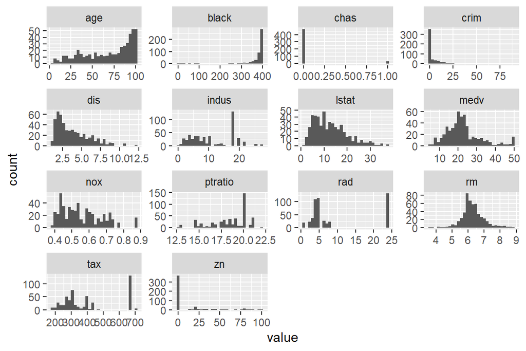

```r
gather(Boston) %>% ggplot(aes(value)) + facet_wrap("key", scales = "free") + geom_histogram()
```

As seen in the descriptive statics and histograms above, great number of the variables are highly skewed. That’s also the case with the variable of my main interest, crime rates. That means there are low crime rates in generally in Boston.

Next, to see the relationships between the variables, I’m going to plot a correlation matrix. I eliminated all the correlations that were not significant (p > .05 at 95 % confidence level). The eliminated ones are marked with crosses.

```r
cor_matrix<-cor(Boston) %>% round(digits = 2)
cor_matrix
```

```
##          crim    zn indus  chas   nox    rm   age   dis   rad   tax ptratio
## crim     1.00 -0.20  0.41 -0.06  0.42 -0.22  0.35 -0.38  0.63  0.58    0.29
## zn      -0.20  1.00 -0.53 -0.04 -0.52  0.31 -0.57  0.66 -0.31 -0.31   -0.39
## indus    0.41 -0.53  1.00  0.06  0.76 -0.39  0.64 -0.71  0.60  0.72    0.38
## chas    -0.06 -0.04  0.06  1.00  0.09  0.09  0.09 -0.10 -0.01 -0.04   -0.12
## nox      0.42 -0.52  0.76  0.09  1.00 -0.30  0.73 -0.77  0.61  0.67    0.19
## rm      -0.22  0.31 -0.39  0.09 -0.30  1.00 -0.24  0.21 -0.21 -0.29   -0.36
## age      0.35 -0.57  0.64  0.09  0.73 -0.24  1.00 -0.75  0.46  0.51    0.26
## dis     -0.38  0.66 -0.71 -0.10 -0.77  0.21 -0.75  1.00 -0.49 -0.53   -0.23
## rad      0.63 -0.31  0.60 -0.01  0.61 -0.21  0.46 -0.49  1.00  0.91    0.46
## tax      0.58 -0.31  0.72 -0.04  0.67 -0.29  0.51 -0.53  0.91  1.00    0.46
## ptratio  0.29 -0.39  0.38 -0.12  0.19 -0.36  0.26 -0.23  0.46  0.46    1.00
## black   -0.39  0.18 -0.36  0.05 -0.38  0.13 -0.27  0.29 -0.44 -0.44   -0.18
## lstat    0.46 -0.41  0.60 -0.05  0.59 -0.61  0.60 -0.50  0.49  0.54    0.37
## medv    -0.39  0.36 -0.48  0.18 -0.43  0.70 -0.38  0.25 -0.38 -0.47   -0.51
##         black lstat  medv
## crim    -0.39  0.46 -0.39
## zn       0.18 -0.41  0.36
## indus   -0.36  0.60 -0.48
## chas     0.05 -0.05  0.18
## nox     -0.38  0.59 -0.43
## rm       0.13 -0.61  0.70
## age     -0.27  0.60 -0.38
## dis      0.29 -0.50  0.25
## rad     -0.44  0.49 -0.38
## tax     -0.44  0.54 -0.47
## ptratio -0.18  0.37 -0.51
## black    1.00 -0.37  0.33
## lstat   -0.37  1.00 -0.74
## medv     0.33 -0.74  1.00
```

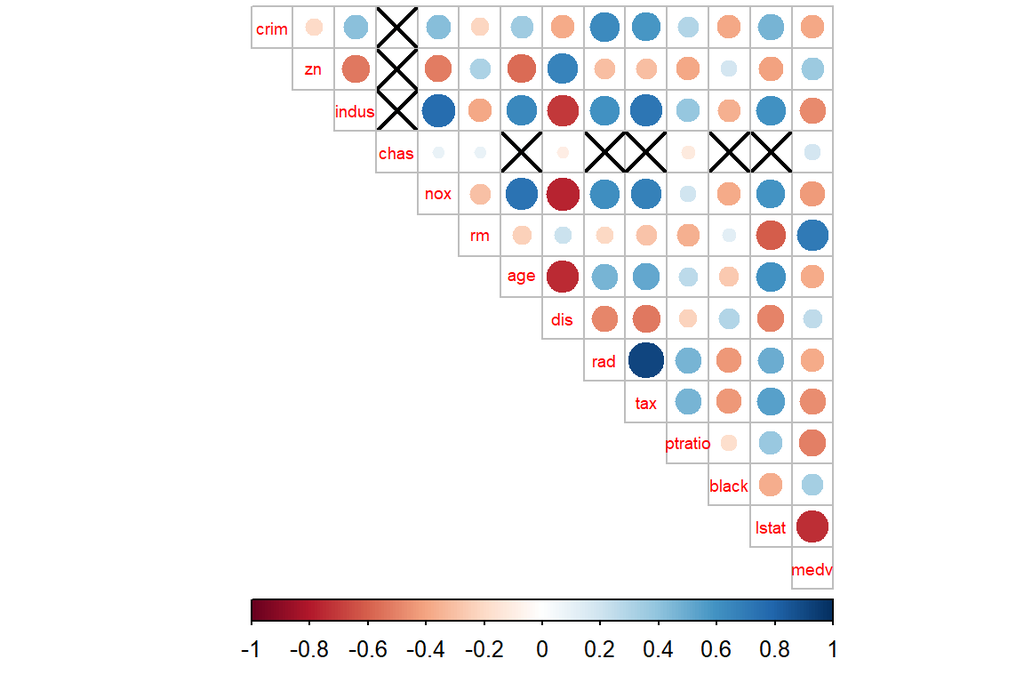

```r
pvalues <-cor.mtest(Boston, conf.level = .95)
corrplot(cor_matrix, method= "circle", type="upper", cl.pos="b", tl.pos="d", tl.cex = 0.6, number.cex=0.5,p.mat=pvalues$p, sig.level=0.05)
```

As seen above, there seems to be strong positive correlation between access to highways (rad) and property-tax rates (tax) (r = .91). There are also strong negative correlations between lower status of the population (lstat) and median value of owner-occupied homes (medv) (r = - .74), proportion of owner-occupied units built prior to 1940 (age) and weighted mean of distances to five Boston employment centres (dis) (r = -.75) and also dis-variable and nitrogen oxides concentration (r = -0.77).

**Standardizing the data set**

Next, I’ll standardize the data set and scale the variables around their mean, which is now 0. As seen in the descriptive table bellow, the distributions are still skewed.

```r
boston_scaled <- scale(Boston)

class(boston_scaled)
```

```
## [1] "matrix" "array"
```

```r
boston_scaled <- as.data.frame(boston_scaled)

summary(boston_scaled)
```

```
##       crim                 zn               indus              chas
##  Min.   :-0.419367   Min.   :-0.48724   Min.   :-1.5563   Min.   :-0.2723
##  1st Qu.:-0.410563   1st Qu.:-0.48724   1st Qu.:-0.8668   1st Qu.:-0.2723
##  Median :-0.390280   Median :-0.48724   Median :-0.2109   Median :-0.2723
##  Mean   : 0.000000   Mean   : 0.00000   Mean   : 0.0000   Mean   : 0.0000
##  3rd Qu.: 0.007389   3rd Qu.: 0.04872   3rd Qu.: 1.0150   3rd Qu.:-0.2723
##  Max.   : 9.924110   Max.   : 3.80047   Max.   : 2.4202   Max.   : 3.6648
##       nox                rm               age               dis
##  Min.   :-1.4644   Min.   :-3.8764   Min.   :-2.3331   Min.   :-1.2658
##  1st Qu.:-0.9121   1st Qu.:-0.5681   1st Qu.:-0.8366   1st Qu.:-0.8049
##  Median :-0.1441   Median :-0.1084   Median : 0.3171   Median :-0.2790
##  Mean   : 0.0000   Mean   : 0.0000   Mean   : 0.0000   Mean   : 0.0000
##  3rd Qu.: 0.5981   3rd Qu.: 0.4823   3rd Qu.: 0.9059   3rd Qu.: 0.6617
##  Max.   : 2.7296   Max.   : 3.5515   Max.   : 1.1164   Max.   : 3.9566
##       rad               tax             ptratio            black
##  Min.   :-0.9819   Min.   :-1.3127   Min.   :-2.7047   Min.   :-3.9033
##  1st Qu.:-0.6373   1st Qu.:-0.7668   1st Qu.:-0.4876   1st Qu.: 0.2049
##  Median :-0.5225   Median :-0.4642   Median : 0.2746   Median : 0.3808
##  Mean   : 0.0000   Mean   : 0.0000   Mean   : 0.0000   Mean   : 0.0000
##  3rd Qu.: 1.6596   3rd Qu.: 1.5294   3rd Qu.: 0.8058   3rd Qu.: 0.4332
##  Max.   : 1.6596   Max.   : 1.7964   Max.   : 1.6372   Max.   : 0.4406
##      lstat              medv
##  Min.   :-1.5296   Min.   :-1.9063
##  1st Qu.:-0.7986   1st Qu.:-0.5989
##  Median :-0.1811   Median :-0.1449
##  Mean   : 0.0000   Mean   : 0.0000
##  3rd Qu.: 0.6024   3rd Qu.: 0.2683
##  Max.   : 3.5453   Max.   : 2.9865
```

```r
describe(boston_scaled)
```

```
##         vars   n mean sd median trimmed  mad   min  max range  skew kurtosis
## crim       1 506    0  1  -0.39   -0.22 0.04 -0.42 9.92 10.34  5.19    36.60
## zn         2 506    0  1  -0.49   -0.27 0.00 -0.49 3.80  4.29  2.21     3.95
## indus      3 506    0  1  -0.21   -0.03 1.37 -1.56 2.42  3.98  0.29    -1.24
## chas       4 506    0  1  -0.27   -0.27 0.00 -0.27 3.66  3.94  3.39     9.48
## nox        5 506    0  1  -0.14   -0.08 1.12 -1.46 2.73  4.19  0.72    -0.09
## rm         6 506    0  1  -0.11   -0.05 0.73 -3.88 3.55  7.43  0.40     1.84
## age        7 506    0  1   0.32    0.09 1.03 -2.33 1.12  3.45 -0.60    -0.98
## dis        8 506    0  1  -0.28   -0.12 0.91 -1.27 3.96  5.22  1.01     0.46
## rad        9 506    0  1  -0.52   -0.09 0.34 -0.98 1.66  2.64  1.00    -0.88
## tax       10 506    0  1  -0.46   -0.05 0.64 -1.31 1.80  3.11  0.67    -1.15
## ptratio   11 506    0  1   0.27    0.10 0.79 -2.70 1.64  4.34 -0.80    -0.30
## black     12 506    0  1   0.38    0.29 0.09 -3.90 0.44  4.34 -2.87     7.10
## lstat     13 506    0  1  -0.18   -0.11 1.00 -1.53 3.55  5.07  0.90     0.46
## medv      14 506    0  1  -0.14   -0.11 0.64 -1.91 2.99  4.89  1.10     1.45
##           se
## crim    0.04
## zn      0.04
## indus   0.04
## chas    0.04
## nox     0.04
## rm      0.04
## age     0.04
## dis     0.04
## rad     0.04
## tax     0.04
## ptratio 0.04
## black   0.04
## lstat   0.04
## medv    0.04
```

Next, I’ll create a new categorical variable of the crime rates. I’ll use the quantiles as the break points in the categorical variable. See bellow a table of the new crime variable.

Then, I’ll drop the old crime rate variable and divide the dataset to train and test sets, so that 80% of the data belongs to the train set.

```r
#Save categories of crime rate
bins <- quantile(boston_scaled$crim)

#new variable
crime <- cut(boston_scaled$crim, breaks = bins, include.lowest = TRUE, labels = c("low", "med_low", "med_high", "high"))
table(crime)
```

```
## crime
##      low  med_low med_high     high
##      127      126      126      127
```

```r
# remove original crim from the dataset
boston_scaled <- dplyr::select(boston_scaled, -crim)

# add the new categorical value to scaled data
boston_scaled <- data.frame(boston_scaled, crime)

# number of rows in the Boston dataset
n <- nrow(boston_scaled)

# choose randomly 80% of the rows
ind <- sample(n,  size = n * 0.8)

# create train set
train <- boston_scaled[ind,]

# create test set
test <- boston_scaled[-ind,]

# save the correct classes from test data
correct_classes <- test$crime

# remove the crime variable from test data
test <- dplyr::select(test, -crime)
```

##### **Linear Discriminant analysis**

```r
# linear discriminant analysis
lda.fit <- lda(crime ~ ., data = train)

# print the lda.fit object
lda.fit
```

```
## Call:
## lda(crime ~ ., data = train)
##
## Prior probabilities of groups:
##       low   med_low  med_high      high
## 0.2599010 0.2351485 0.2376238 0.2673267
##
## Group means:
##                   zn      indus        chas        nox         rm        age
## low       1.07593770 -0.8880589 -0.08484810 -0.8849464  0.4974516 -0.8744208
## med_low  -0.09119085 -0.2755328 -0.02367011 -0.5660352 -0.1083058 -0.3734340
## med_high -0.37826080  0.1818864  0.13778554  0.3601386  0.1018083  0.4166130
## high     -0.48724019  1.0169921 -0.01714665  1.0450782 -0.4657654  0.7915624
##                 dis        rad        tax    ptratio       black       lstat
## low       0.8398145 -0.7007702 -0.7435356 -0.4558831  0.38479989 -0.78282565
## med_low   0.3342593 -0.5490805 -0.4253025 -0.1019872  0.34262802 -0.14081794
## med_high -0.3627834 -0.4219935 -0.3283010 -0.3302201  0.08509777  0.05468073
## high     -0.8569763  1.6393984  1.5149640  0.7822555 -0.79340042  0.92768028
##                 medv
## low       0.55344060
## med_low   0.01325749
## med_high  0.19577108
## high     -0.69913622
##
## Coefficients of linear discriminants:
##                 LD1         LD2         LD3
## zn       0.05660122  0.88503490 -0.99964704
## indus    0.00642471 -0.25019305  0.03915119
## chas    -0.07147433 -0.04796170  0.11225565
## nox      0.41887713 -0.63018640 -1.26915728
## rm      -0.12305610 -0.04507277 -0.16012746
## age      0.16551907 -0.29542086 -0.32903886
## dis     -0.03316568 -0.45744176  0.19530753
## rad      3.41407532  0.87038878 -0.36577464
## tax      0.02650823 -0.06481034  1.14634414
## ptratio  0.09349059  0.14409567 -0.32584264
## black   -0.13147881  0.03683913  0.16459482
## lstat    0.25901111 -0.31585293  0.23851880
## medv     0.21963405 -0.42214506 -0.26583342
##
## Proportion of trace:
##    LD1    LD2    LD3
## 0.9539 0.0332 0.0129
```

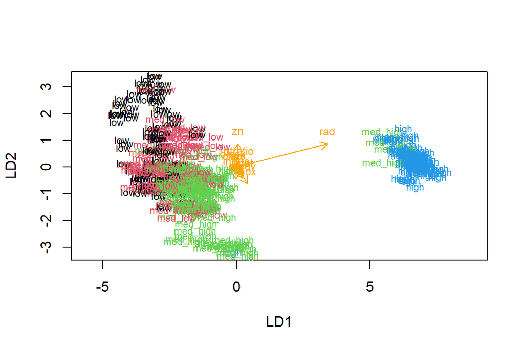

```r
# the function for lda biplot arrows
lda.arrows <- function(x, myscale = 1, arrow_heads = 0.1, color = "orange", tex = 0.75, choices = c(1,2)){
  heads <- coef(x)
  arrows(x0 = 0, y0 = 0,
         x1 = myscale * heads[,choices[1]],
         y1 = myscale * heads[,choices[2]], col=color, length = arrow_heads)
  text(myscale * heads[,choices], labels = row.names(heads),
       cex = tex, col=color, pos=3)
}

# target classes as numeric
classes <- as.numeric(train$crime)

# plot the lda results
plot(lda.fit, dimen = 2, col = classes, pch = classes)
lda.arrows(lda.fit, myscale = 1)
```

```r
# predict classes with test data
lda.pred <- predict(lda.fit, newdata = test)

# cross tabulate the results
table(correct = correct_classes, predicted = lda.pred$class)
```

```
##           predicted
## correct    low med_low med_high high
##   low        8      14        0    0
##   med_low    4      22        5    0
##   med_high   0       7       21    2
##   high       0       0        0   19
```

The plot shows that the high crime rate areas groups together relatively well, but the other groups are more overlapping with each other.

Seems that the access to radial highways separates relatively well the high crime rate group. Summary of the model shows that mean of the access to radial highways-variable is high in the high crime rate group, and lower in the others. The findings indicates that there are more crimes happening in the areas of Boston with easy access to highways.

When we look at the prediction table, we can see that the model groups the high crime rate areas pretty correctly but had more difficulties with the other groups.

##### **K-means**

I’ll start with reloading the Boston data set and standardize it.Then, I’ll calculate the distances between the observations. I’ll run it using both Euclidean (the first table) and Manhattan (the second one) methods.

```r
data('Boston')
Boston = scale(Boston)
Boston <- as.data.frame(Boston)

# euclidean distance matrix
dist_eu <- dist(Boston)
summary(dist_eu)
```

```
##    Min. 1st Qu.  Median    Mean 3rd Qu.    Max.
##  0.1343  3.4625  4.8241  4.9111  6.1863 14.3970
```

```r
# manhattan distance matrix
dist_man <- dist(Boston, method = 'manhattan')
summary(dist_man)
```

```
##    Min. 1st Qu.  Median    Mean 3rd Qu.    Max.
##  0.2662  8.4832 12.6090 13.5488 17.7568 48.8618
```

Next, I’m going to run the k-means algorithm for different cluster numbers. My maximum number for clusters is 10. Based on the plot bellow, the optimal number of clusters is two.

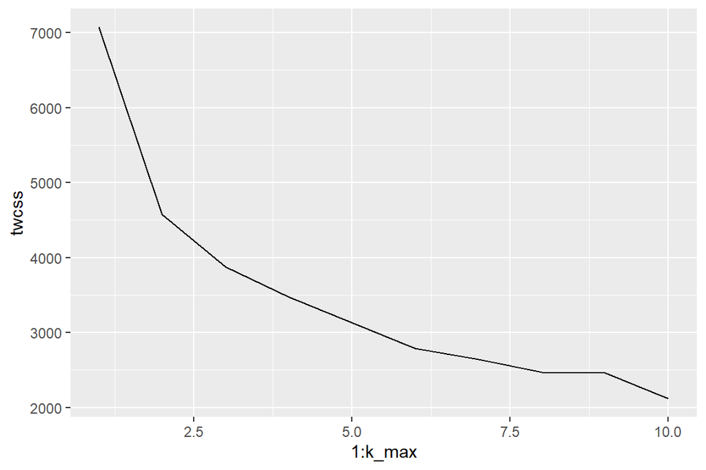

```r
# determine the best number of clusters
k_max <- 10
# calculate the total within sum of squares
twcss <- sapply(1:k_max, function(k){kmeans(Boston, k)$tot.withinss})
# visualize the results
qplot(x = 1:k_max, y = twcss, geom = 'line')
```

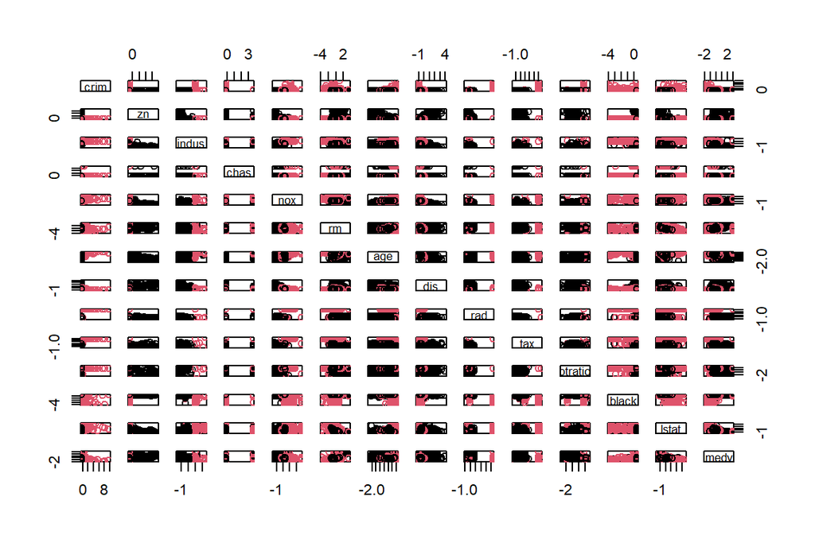

```r
# k-means clustering
km <-kmeans(Boston, centers = 2)

# plot the whole Boston dataset with clusters
pairs(Boston, col = km$cluster)
```

# 23.11.2020

# **Exercise 5: Clustering and classification**

**Description of the analysed data**

The data set used in these analysis consists of 8 variables (n = 155) and all the variables in the data are continuous. The data combines several indicators from most countries in the world. The variables measure phenomena related to health & knowledge and gender empowerment

Read more about the data from [here](http://hdr.undp.org/en/content/human-development-index-hdi)

##### **Here’s a little glossary to help understand the short terms used in tables:**

**GNI** = Gross National Income per capita

**Life.Exp** = Life expectancy at birth

**Edu.Exp** = Expected years of schooling

**Mat.Mor** = Maternal mortality ratio

**Ado.Birth** = Adolescent birth rate

**Parli.F** = Percetange of female representatives in parliament

**Edu2.FM** = Proportion of females/ males with at least secondary education

**Labo.FM** = Proportion of females/ males in the labour force

##### **Find bellow the descriptions of variables in the data set**

```r
#Open packages
library(psych)
library(tidyverse)
library(corrplot)
library(GGally)
library(ggplot2)

#Read the data

human <- read.table("http://s3.amazonaws.com/assets.datacamp.com/production/course_2218/datasets/human2.txt", sep=",", header=TRUE)

#Checking the data
str(human)
```

```r
describe(human)
```

```
##           vars   n     mean       sd   median  trimmed      mad    min
## Edu2.FM      1 155     0.85     0.24     0.94     0.87     0.12   0.17
## Labo.FM      2 155     0.71     0.20     0.75     0.73     0.17   0.19
## Edu.Exp      3 155    13.18     2.84    13.50    13.24     2.97   5.40
## Life.Exp     4 155    71.65     8.33    74.20    72.40     7.56  49.00
## GNI          5 155 17627.90 18543.85 12040.00 14552.58 13337.47 581.00
## Mat.Mor      6 155   149.08   211.79    49.00   104.70    63.75   1.00
## Ado.Birth    7 155    47.16    41.11    33.60    41.62    35.73   0.60
## Parli.F      8 155    20.91    11.49    19.30    20.32    11.42   0.00
##                 max     range  skew kurtosis      se
## Edu2.FM        1.50      1.33 -0.76     0.55    0.02
## Labo.FM        1.04      0.85 -0.87     0.05    0.02
## Edu.Exp       20.20     14.80 -0.20    -0.34    0.23
## Life.Exp      83.50     34.50 -0.76    -0.15    0.67
## GNI       123124.00 122543.00  2.14     6.83 1489.48
## Mat.Mor     1100.00   1099.00  2.03     4.16   17.01
## Ado.Birth    204.80    204.20  1.13     0.89    3.30
## Parli.F       57.50     57.50  0.55    -0.10    0.92
```

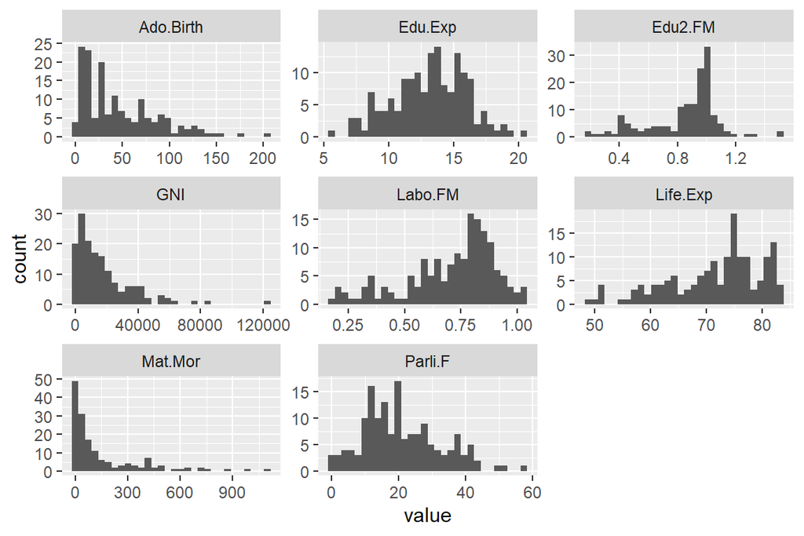

```r
gather(human) %>% ggplot(aes(value)) + facet_wrap("key", scales = "free") + geom_histogram()
```

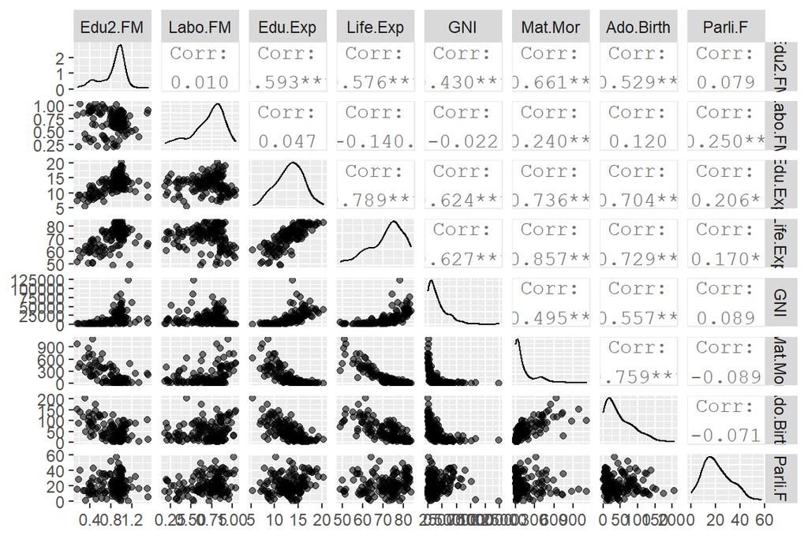

```r
p <- ggpairs(human, mapping = aes(alpha = 0.3), lower = list(combo = wrap("facethist", bins = 20)))
p
```

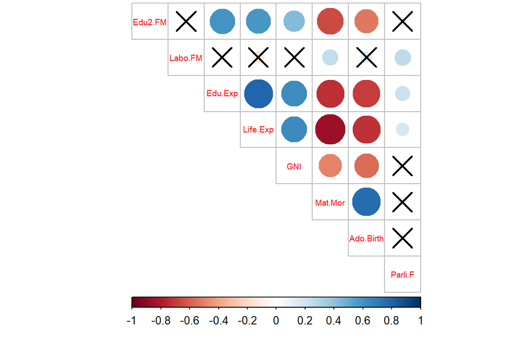

```r
cor_matrix<-cor(human) %>% round(digits = 2)
pvalues <-cor.mtest(human, conf.level = .95)
corrplot(cor_matrix, method= "circle", type="upper", cl.pos="b", tl.pos="d", tl.cex = 0.6, number.cex=0.5,p.mat=pvalues$p, sig.level=0.05)
```

When we look at the descriptive table and histograms above, we can see that there are couple variables that are highly skewed. Adolescent birth rate and Maternal mortality ratio seem to be quite low in most of the countries. Also GNI (Gross National Income per capita) is under 40 000 in the majority of the countries.

Also, when we look at the ggpairs output and correlation matrix, we can see that there are high positive correlation between Adolescent birth rate and Maternal mortality ratio. Life expectancy at birth correlates negatively with both maternal morality ration and adolescent birth rate. There are also high negative correlation between Expected years of schooling and Adolescent birth rate. On the line with other strong correlations, there are also strong positive correlation between Expected years of schooling and Life expectancy at birth.

#### **principal component analysis**

First, I’ll perform principal component analysis (PCA) on the not standardized data.

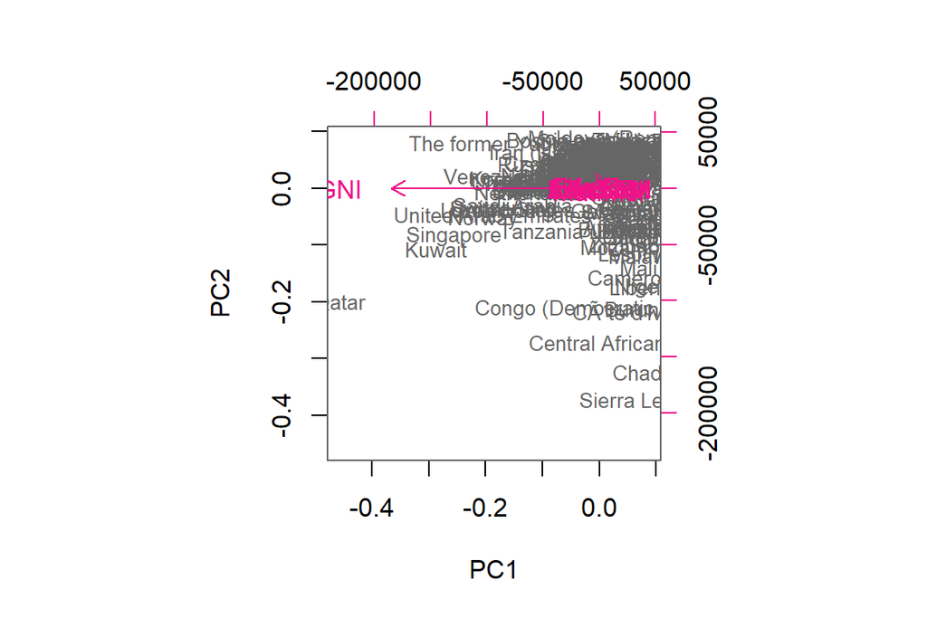

```r
pca_human <- prcomp(human)
biplot(pca_human, choices = 1:2, cex = c(0.8, 1), col = c("grey40", "deeppink2"))
```

```r
summary(pca_human)
```

```
## Importance of components:
##                              PC1      PC2   PC3   PC4   PC5   PC6    PC7    PC8
## Standard deviation     1.854e+04 185.5219 25.19 11.45 3.766 1.566 0.1912 0.1591
## Proportion of Variance 9.999e-01   0.0001  0.00  0.00 0.000 0.000 0.0000 0.0000
## Cumulative Proportion  9.999e-01   1.0000  1.00  1.00 1.000 1.000 1.0000 1.0000
```

As seen above, GNI explains all of the variability.However, the GNI values’ variances are higher than the other variables’. The PCA treats the variable with the largest variance as the most important one. Therefore, it is important to standardize the data.

Next, to identify the real dimensions, I’ll repeat the analysis with standardized data.

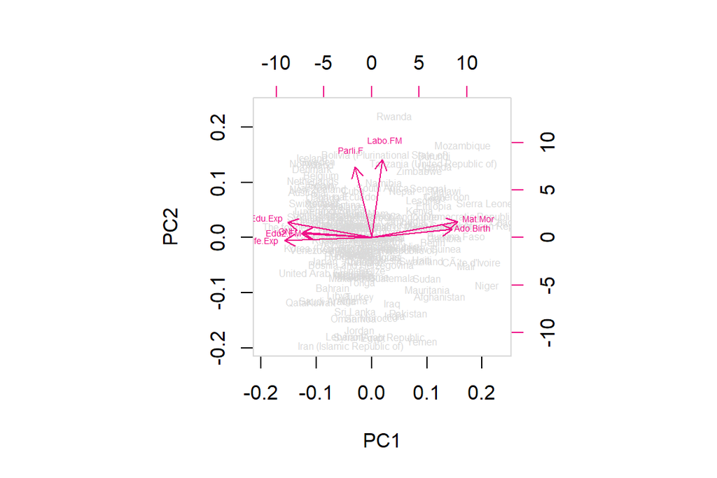

```r
human_ <- scale(human)

pca_human_ <- prcomp(human_)

biplot(pca_human_, choices = 1:2, cex = c(0.5, 0.45), col = c("grey85", "deeppink2"))
```

```r
summary(pca_human_)
```

```
## Importance of components:
##                           PC1    PC2     PC3     PC4     PC5     PC6     PC7
## Standard deviation     2.0708 1.1397 0.87505 0.77886 0.66196 0.53631 0.45900
## Proportion of Variance 0.5361 0.1624 0.09571 0.07583 0.05477 0.03595 0.02634
## Cumulative Proportion  0.5361 0.6984 0.79413 0.86996 0.92473 0.96069 0.98702
##                            PC8
## Standard deviation     0.32224
## Proportion of Variance 0.01298
## Cumulative Proportion  1.00000
```

As seen bellow, now there are several variables that explaining the variance.

Expected years of schooling, GNI, life expectancy at birth, maternal mortality and adolescent birth rate load to PC1 that explains 54% of the total variability in the data. When compared to the other variables, maternal mortality and adolescent birth rate seems to operate to an opposite direction. That indicates that these two variables correlate negatively with the other variables on PC1. We already notice this same then above when we looked at the correlations between the variables. Looks like there is less maternal mortality and adolescent births in countries with higher educated citizens, higher GNI and longer life expectancy.

PC2 explains 16 % of the total variability in the data. Only Proportion of females/ males in the labors force and Percetange of female representatives in parliament load to PC2. This PC seems to describe gender equality.

The variables loading to PC1 seems to correlate bit more with the PC1 axis (the angles are smaller) than the other variables correlate with PC2 axis.

#### **Multiple Correspondence Analysis**

For the next analysis I’m using “tea” data set from FactoMineR R package. The data set contains information of tea drinking habits (n = 300) and there are 36 variables in the data set.

##### **Find bellow the descriptions of variables in the data set**

```r
library(FactoMineR)
library(dplyr)
library(tidyr)

data(tea)

str(tea)
```

```
## 'data.frame':    300 obs. of  36 variables:
##  $ breakfast       : Factor w/ 2 levels "breakfast","Not.breakfast": 1 1 2 2 1 2 1 2 1 1 ...
##  $ tea.time        : Factor w/ 2 levels "Not.tea time",..: 1 1 2 1 1 1 2 2 2 1 ...
##  $ evening         : Factor w/ 2 levels "evening","Not.evening": 2 2 1 2 1 2 2 1 2 1 ...
##  $ lunch           : Factor w/ 2 levels "lunch","Not.lunch": 2 2 2 2 2 2 2 2 2 2 ...
##  $ dinner          : Factor w/ 2 levels "dinner","Not.dinner": 2 2 1 1 2 1 2 2 2 2 ...
##  $ always          : Factor w/ 2 levels "always","Not.always": 2 2 2 2 1 2 2 2 2 2 ...
##  $ home            : Factor w/ 2 levels "home","Not.home": 1 1 1 1 1 1 1 1 1 1 ...
##  $ work            : Factor w/ 2 levels "Not.work","work": 1 1 2 1 1 1 1 1 1 1 ...
##  $ tearoom         : Factor w/ 2 levels "Not.tearoom",..: 1 1 1 1 1 1 1 1 1 2 ...
##  $ friends         : Factor w/ 2 levels "friends","Not.friends": 2 2 1 2 2 2 1 2 2 2 ...
##  $ resto           : Factor w/ 2 levels "Not.resto","resto": 1 1 2 1 1 1 1 1 1 1 ...
##  $ pub             : Factor w/ 2 levels "Not.pub","pub": 1 1 1 1 1 1 1 1 1 1 ...
##  $ Tea             : Factor w/ 3 levels "black","Earl Grey",..: 1 1 2 2 2 2 2 1 2 1 ...
##  $ How             : Factor w/ 4 levels "alone","lemon",..: 1 3 1 1 1 1 1 3 3 1 ...
```

[output cut: 22 more lines]

Since there is so many variables, I decided to select only some of them for the sake of clearer looking analysis. Bellow you can see descriptive statics and histograms of the variables I selected.

```r
keep_columns <- c("Tea", "How", "how", "breakfast", "where", "sex")
tea_time <- dplyr::select(tea, one_of(keep_columns))
summary(tea_time)
```

```
##         Tea         How                      how              breakfast
##  black    : 74   alone:195   tea bag           :170   breakfast    :144
##  Earl Grey:193   lemon: 33   tea bag+unpackaged: 94   Not.breakfast:156
##  green    : 33   milk : 63   unpackaged        : 36
##                  other:  9
##                   where     sex
##  chain store         :192   F:178
##  chain store+tea shop: 78   M:122
##  tea shop            : 30
##
```

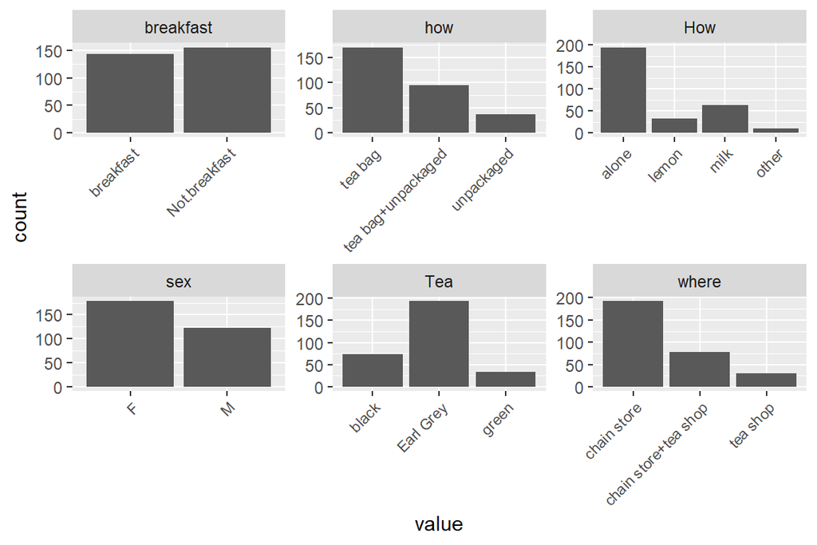

```r
gather(tea_time) %>% ggplot(aes(value)) + facet_wrap("key", scales = "free") + geom_bar() + theme(axis.text.x = element_text(angle = 45, hjust = 1, size = 8))
```

```r
# multiple correspondence analysis
mca <- MCA(tea_time, graph = F)

# summary of the model
summary(mca)
```

```
##
## Call:
## MCA(X = tea_time, graph = F)
##
##
## Eigenvalues
##                        Dim.1   Dim.2   Dim.3   Dim.4   Dim.5   Dim.6   Dim.7
## Variance               0.282   0.266   0.215   0.185   0.172   0.157   0.141
## % of var.             15.371  14.500  11.742  10.073   9.373   8.578   7.699
## Cumulative % of var.  15.371  29.872  41.614  51.687  61.060  69.638  77.337
##                        Dim.8   Dim.9  Dim.10  Dim.11
## Variance               0.135   0.130   0.087   0.063
## % of var.              7.370   7.109   4.732   3.452
## Cumulative % of var.  84.707  91.816  96.548 100.000
##
## Individuals (the 10 first)
##                       Dim.1    ctr   cos2    Dim.2    ctr   cos2    Dim.3
## 1                  | -0.077  0.007  0.005 | -0.308  0.119  0.076 |  0.720
## 2                  | -0.388  0.178  0.091 | -0.093  0.011  0.005 |  0.889
## 3                  | -0.304  0.109  0.138 | -0.491  0.303  0.360 | -0.457
## 4                  | -0.124  0.018  0.019 | -0.577  0.417  0.416 | -0.098
## 5                  | -0.244  0.071  0.072 | -0.412  0.213  0.206 |  0.256
## 6                  | -0.124  0.018  0.019 | -0.577  0.417  0.416 | -0.098
## 7                  | -0.244  0.071  0.072 | -0.412  0.213  0.206 |  0.256
## 8                  | -0.267  0.084  0.044 | -0.258  0.083  0.041 |  0.535
## 9                  | -0.235  0.065  0.028 |  0.853  0.913  0.367 |  0.471
## 10                 |  0.063  0.005  0.002 |  0.828  0.860  0.368 |  0.408
##                       ctr   cos2
## 1                   0.803  0.417 |
## 2                   1.223  0.478 |
## 3                   0.323  0.311 |
## 4                   0.015  0.012 |
## 5                   0.101  0.079 |
## 6                   0.015  0.012 |
## 7                   0.101  0.079 |
## 8                   0.443  0.176 |
## 9                   0.344  0.112 |
## 10                  0.257  0.089 |
##
## Categories (the 10 first)
```

[output cut: 16 more lines]

```
## lemon                4.871 |  -0.463   1.828   0.027  -2.816 |
## milk                 1.185 |   1.128  20.670   0.338  10.052 |
## other                5.874 |   1.207   3.386   0.045   3.672 |
## tea bag            -11.182 |   0.171   1.281   0.038   3.379 |
## tea bag+unpackaged  11.850 |  -0.372   3.348   0.063  -4.340 |
## unpackaged           0.137 |   0.163   0.247   0.004   1.042 |
##
## Categorical variables (eta2)
##                      Dim.1 Dim.2 Dim.3
## Tea                | 0.134 0.084 0.315 |
## How                | 0.077 0.233 0.410 |
## how                | 0.663 0.504 0.063 |
## breakfast          | 0.037 0.065 0.242 |
## where              | 0.700 0.692 0.020 |
## sex                | 0.080 0.017 0.241 |
```

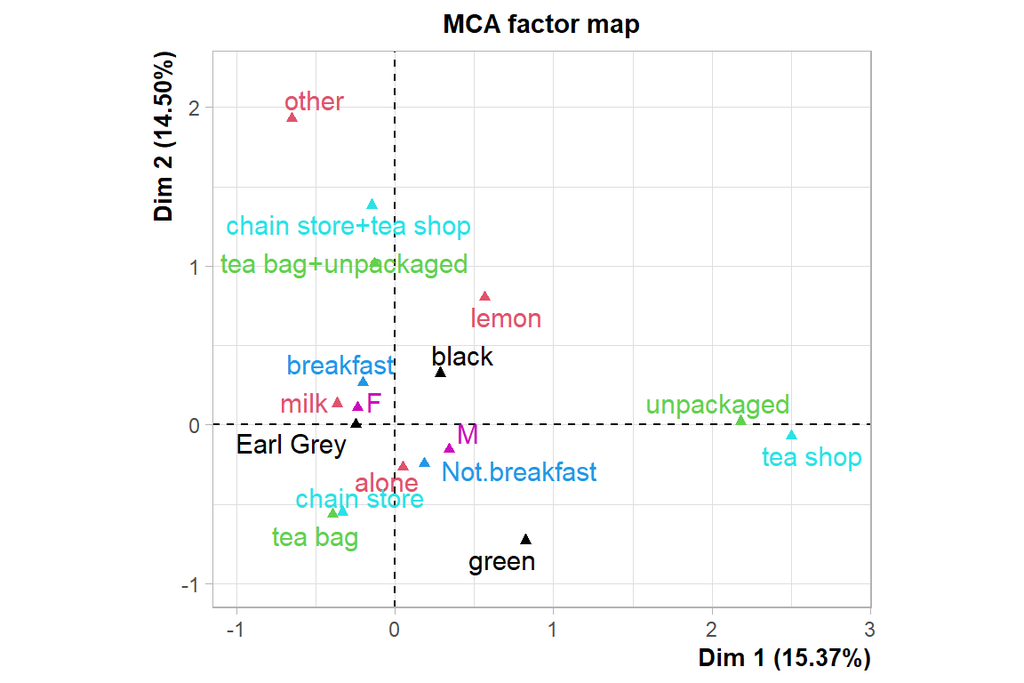

```r
# visualize MCA
plot(mca, invisible=c("ind"), habillage = "quali")
```

Above you can see MCA matrix and MCA factor map.

Both, the first and the second dimension, explain roughly 15 % of the variance. Together they explain 30 % of all the variance which is not that much. When we look at the factor map, we can see that being female, drinking earl grey, drinking tea with milk and drinking it at the breakfast. That means that these variable categories have similarities. Also buying tea bags and buying tea from chain store are very similar. Whereas drinking tea with something else than lemon, milk or “pure” (variable *other* in the map) is situated far away from the other variable categories in factor map. That tells us that the variable has the least similarities with the other variables (Maybe because that “something else” in your tea usually indicates to some kind of alcohol beverage. Adding alcohol to your tea might not have that much in common with the other variables that concern daily usage of tea).

# 30.11.2020

# **Exercise 6: Analysis of longitudinal data**

#### **Description of analysed data sets**

For this weeks exercise, I’m using two data sets. First I’ll start with a data set called ratsl. That data set contains information from a nutrition study conducted in three groups of rats. The groups were put on different diets, and each rats’ body weight (grams) was recorded repeatedly over a 9-week period.

The second data set contains information of some medical treatments. the data set includes BPRS rates (brief word for the brief psychiatric rating scale) of two different treatment groups of 20 man. These patients BPRS levels were followed every week for 8 weeks.

Read more about the data sets from [this books](https://mooc.helsinki.fi/pluginfile.php/143981/course/section/5444/MABS4IODS.pdf) chapters 8 and 9.

```r
#Opening packages
library(psych)
library(tidyr)
library(ggplot2)
library(tidyverse)
library(knitr)

#Reading the data
ratsl <- read.table("data/RATSL.txt")
bprsl <- read.table("data/BPRSL.txt")

#Checking the data
str(ratsl)
str(bprsl)

#Looks that I have to factor some of the variables again
bprsl$treatment <- factor(bprsl$treatment)
bprsl$subject <- factor(bprsl$subject)

ratsl$ID <- factor(ratsl$ID)
ratsl$Group <- factor(ratsl$Group)

str(ratsl)
str(bprsl)
#Now everything is okey for the analysis
```

First, I’ll start with analyzing ratsl by graphical displays and summary measure approach.

```r
summary(ratsl)
```

```
##        ID      Group      WDs                 rats            time
##  1      : 11   1:88   Length:176         Min.   :225.0   Min.   : 1.00
##  2      : 11   2:44   Class :character   1st Qu.:267.0   1st Qu.:15.00
##  3      : 11   3:44   Mode  :character   Median :344.5   Median :36.00
##  4      : 11                             Mean   :384.5   Mean   :33.55
##  5      : 11                             3rd Qu.:511.2   3rd Qu.:50.00
##  6      : 11                             Max.   :628.0   Max.   :64.00
##  (Other):110
```

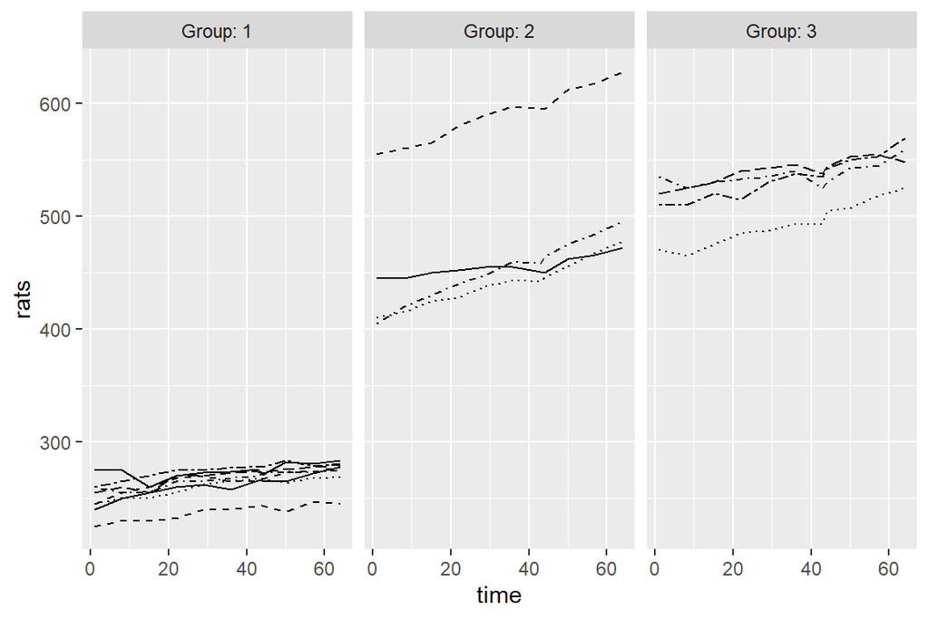

```r
# Draw the plot
ggplot(ratsl, aes(x = time, y = rats, linetype = ID)) +
  geom_line() +
  scale_linetype_manual(values = rep(1:10, times=4)) +
  facet_grid(. ~ Group, labeller = label_both) +
  theme(legend.position = "none") +
  scale_y_continuous(limits = c(min(ratsl$rats), max(ratsl$rats)))
```

From the graphic above we can see lines that show rats’ individual growth in time in each three groups. In group 1, the rats seems to be generally smaller than in other groups. In group 2, there seem to be one giant rat but the other group 2 members are smaller that rats in group 3. Generally it looks like the rats’ weight increase in all three groups, but the growth is more settle in group 1.

Next I’ll standardize the weight of the rats to see how it effects to the results.

```r
# Standardise the variable rats
ratsl2 <- ratsl %>%
  group_by(time) %>%
  mutate(std_weight = (rats - mean(rats))/sd(rats) ) %>%
  ungroup()

# Glimpse the data
glimpse(ratsl2)
```

```
## Rows: 176
## Columns: 6
## $ ID         <fct> 1, 2, 3, 4, 5, 6, 7, 8, 9, 10, 11, 12, 13, 14, 15, 16, 1...
## $ Group      <fct> 1, 1, 1, 1, 1, 1, 1, 1, 2, 2, 2, 2, 3, 3, 3, 3, 1, 1, 1,...
## $ WDs        <chr> "WD1", "WD1", "WD1", "WD1", "WD1", "WD1", "WD1", "WD1", ...
## $ rats       <int> 240, 225, 245, 260, 255, 260, 275, 245, 410, 405, 445, 5...
## $ time       <int> 1, 1, 1, 1, 1, 1, 1, 1, 1, 1, 1, 1, 1, 1, 1, 1, 8, 8, 8,...
## $ std_weight <dbl> -1.0011429, -1.1203857, -0.9613953, -0.8421525, -0.88190...
```

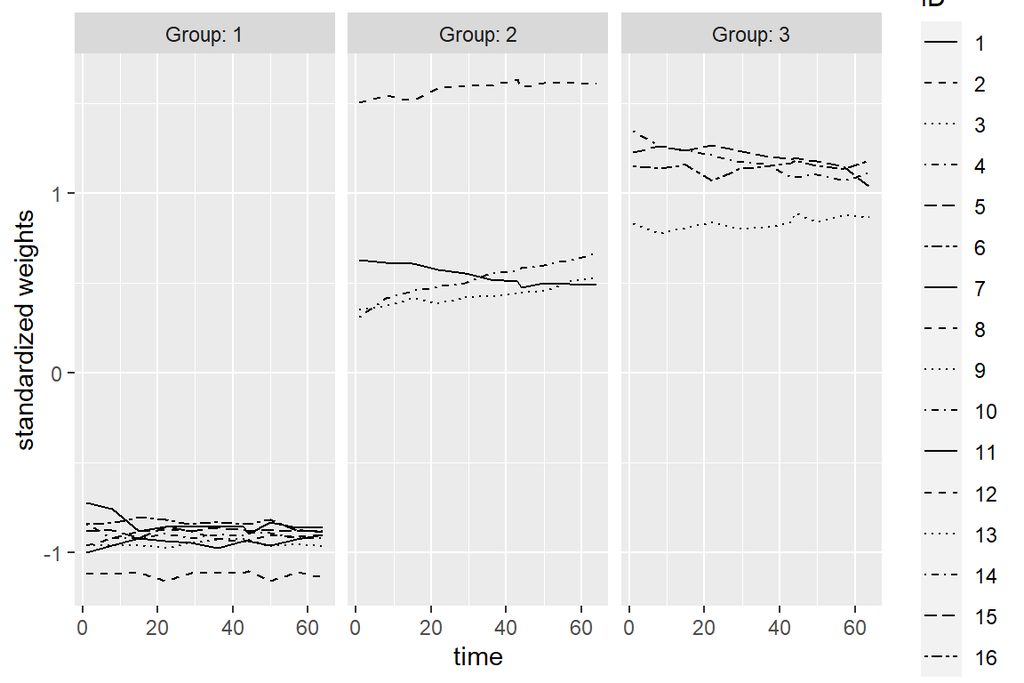

```r
# Plot again with the standardized weights
ggplot(ratsl2, aes(x = time, y = std_weight, linetype = ID)) +
  geom_line() +
  scale_linetype_manual(values = rep(1:10, times=4)) +
  facet_grid(. ~ Group, labeller = label_both) +
  scale_y_continuous(name = "standardized weights")
```

Now when we look above, we can see that now the growth in each group is more settled.

Next, I’ll draw some summary graphs that describe better the change over time in group levels. See bellow a plot figure with averaged over the group-specific means by time point.

```r
# Number of weeks, baseline (week 0) included
n <- ratsl2$time %>% unique() %>% length()

# Summary data with mean and standard error of weight by group and time point
ratss <- ratsl2 %>%
  group_by(Group, time) %>%
  summarise( mean = mean(rats), se = sd(rats)/sqrt(n) ) %>%
  ungroup()
# Glimpse the data
glimpse(ratss)
```

```
## Rows: 33
## Columns: 4
## $ Group <fct> 1, 1, 1, 1, 1, 1, 1, 1, 1, 1, 1, 2, 2, 2, 2, 2, 2, 2, 2, 2, 2...
## $ time  <int> 1, 8, 15, 22, 29, 36, 43, 44, 50, 57, 64, 1, 8, 15, 22, 29, 3...
## $ mean  <dbl> 250.625, 255.000, 254.375, 261.875, 264.625, 265.000, 267.375...
## $ se    <dbl> 4.589478, 3.947710, 3.460116, 4.100800, 3.333956, 3.552939, 3...
```

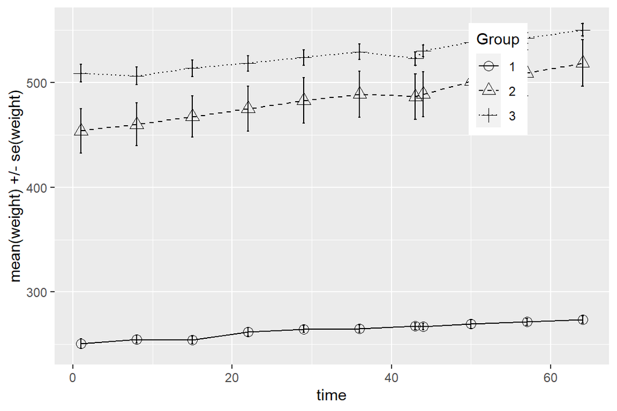

```r
# Plot the mean profiles
ggplot(ratss, aes(x = time, y = mean, linetype = Group, shape = Group)) +
  geom_line() +
  scale_linetype_manual(values = c(1,2,3)) +
  geom_point(size=3) +
  scale_shape_manual(values = c(1,2,3)) +
  geom_errorbar(aes(ymin = mean - se, ymax = mean + se, linetype="1"), width=0.3) +
  theme(legend.position = c(0.8,0.8)) +
  scale_y_continuous(name = "mean(weight) +/- se(weight)")
```

From the plot graph above, we can see that group 1 rats are much smaller than the other rats and their weights don’t increase that much over time. The standard error of group 2 is pretty wide. This must have something to do with the fact that there is one giant rat in group 2. That rat is an outlier. Let’s see next weather there is other outliers in the groups.

```r
# Create a summary data by group and ID with mean as the summary variable (ignoring baseline week 0).
ratsl8S <- ratsl %>%
  filter(time > 0) %>%
  group_by(Group, ID) %>%
  summarise( mean=mean(rats) ) %>%
  ungroup()
# Glimpse the data
glimpse(ratsl8S)
```

```
## Rows: 16
## Columns: 3
## $ Group <fct> 1, 1, 1, 1, 1, 1, 1, 1, 2, 2, 2, 2, 3, 3, 3, 3
## $ ID    <fct> 1, 2, 3, 4, 5, 6, 7, 8, 9, 10, 11, 12, 13, 14, 15, 16
## $ mean  <dbl> 261.0909, 237.6364, 260.1818, 266.5455, 269.4545, 274.7273, 2...
```

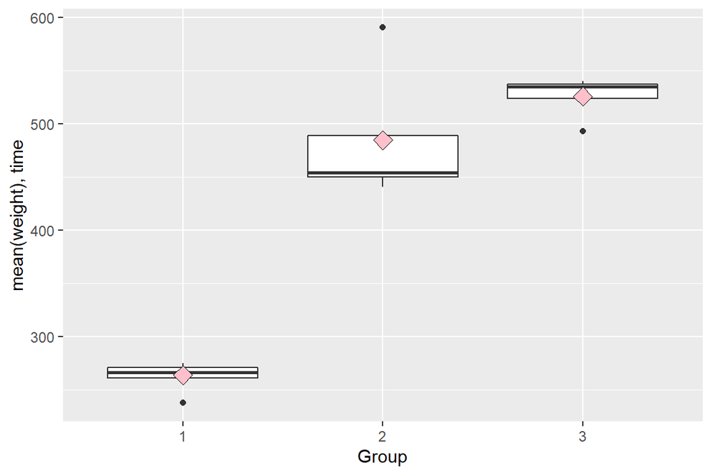

```r
# Draw a boxplot of the mean versus Group
ggplot(ratsl8S, aes(x = Group, y = mean)) +
  geom_boxplot() +
  stat_summary(fun = "mean", geom = "point", shape=23, size=4, fill = "pink") +
  scale_y_continuous(name = "mean(weight), time")
```

```r
#Filltering out the ouliers

ratsl8S1 <- ratsl8S %>%
  filter(ID !=2 & ID !=12 & ID !=13)
```

There seems to be one outlier in each group but the outlier in group 2 is the most obvious one. The outliers in groups 1 and 3, are the rats with the lowest means. I will continue the analyses by excluding all the three outliers.

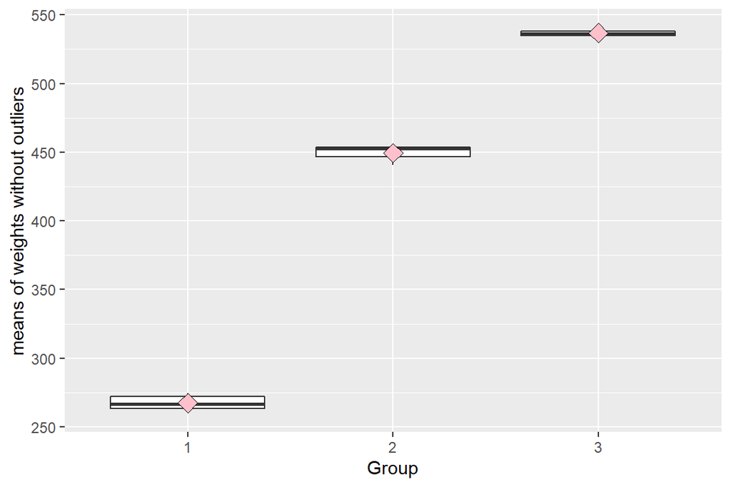

```r
ggplot(ratsl8S1, aes(x = Group, y = mean)) +
  geom_boxplot() +
  stat_summary(fun  = "mean", geom = "point", shape=23, size=4, fill = "pink") +
  scale_y_continuous(name = "means of weights without outliers")
```

Since I have more than two groups, I’ll use ANOVA to explore the statistically significant differences between the groups.

For some reason my Index.rmd file has problems with knitting the ANOVA test (But ANOVA works when I do it in chapter6.Rmd). That’s why I decided to add the ANOVA results here as a pic. If you want to now how I did the analyze, I created separate chapter6_with_anova.rmd and you can find it from [here](https://github.com/sallavei/IODS-project/blob/master/chapter6_with_anova.Rmd).

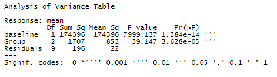

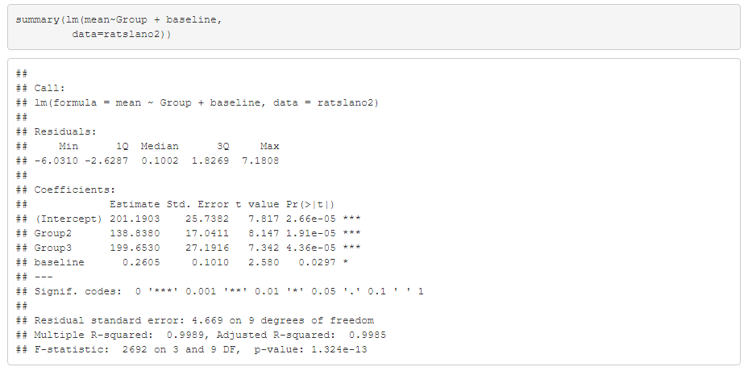

Anova shows that the group differences in rats’ weight is statically significant. The baseline weight is also some what statically significantly associated with the average weight during the follow-up, but when we look at the summary, we can see that the statical significance is only p < .05.

Next I’ll move on the bprs data set and do linear mixed effects model.

Here’s some descriptives of the data set:

```r
summary(bprsl)
```

```
##  treatment    subject       weeks                bprs            week
##  1:180     1      : 18   Length:360         Min.   :18.00   Min.   :0
##  2:180     2      : 18   Class :character   1st Qu.:27.00   1st Qu.:2
##            3      : 18   Mode  :character   Median :35.00   Median :4
##            4      : 18                      Mean   :37.66   Mean   :4
##            5      : 18                      3rd Qu.:43.00   3rd Qu.:6
##            6      : 18                      Max.   :95.00   Max.   :8
##            (Other):252
```

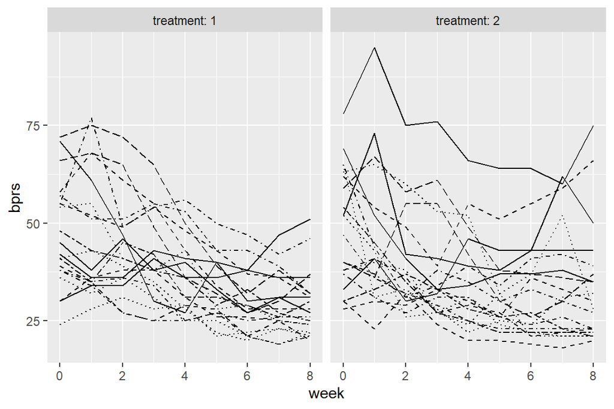

```r
ggplot(bprsl, aes(x = week, y = bprs, linetype = subject)) +
  geom_line() +
  scale_linetype_manual(values = rep(1:10, times=4)) +
  facet_grid(. ~ treatment, labeller = label_both) +
  theme(legend.position = "none") +
  scale_y_continuous(limits = c(min(bprsl$bprs), max(bprsl$bprs)))
```

It’s hard to do any interpretation based on the plot graphs above. Let’s move on to the linear regressions.

```r
Model <- lm(bprs ~ week + treatment, data = bprsl)
summary(Model)
```

```
##
## Call:
## lm(formula = bprs ~ week + treatment, data = bprsl)
##
## Residuals:
##     Min      1Q  Median      3Q     Max
## -22.454  -8.965  -3.196   7.002  50.244
##
## Coefficients:
##             Estimate Std. Error t value Pr(>|t|)
## (Intercept)  46.4539     1.3670  33.982   <2e-16 ***
## week         -2.2704     0.2524  -8.995   <2e-16 ***
## treatment2    0.5722     1.3034   0.439    0.661
## ---
## Signif. codes:  0 '***' 0.001 '**' 0.01 '*' 0.05 '.' 0.1 ' ' 1
##
## Residual standard error: 12.37 on 357 degrees of freedom
## Multiple R-squared:  0.1851, Adjusted R-squared:  0.1806
## F-statistic: 40.55 on 2 and 357 DF,  p-value: < 2.2e-16
```

Looks that Week is significantly related to BPRS, but the treatment group is not. Together the model explains less than 20% of the variation in BPRS (Multiple R-squared is 0.1851).

Then, let’s try random intercept model.

```r
library(lme4)
Model2<- lmer(bprs ~ week + treatment + (1 | subject), data = bprsl, REML = FALSE)
summary(Model2)
```

```
## Linear mixed model fit by maximum likelihood  ['lmerMod']
## Formula: bprs ~ week + treatment + (1 | subject)
##    Data: bprsl
##
##      AIC      BIC   logLik deviance df.resid
##   2748.7   2768.1  -1369.4   2738.7      355
##
## Scaled residuals:
##     Min      1Q  Median      3Q     Max
## -3.0481 -0.6749 -0.1361  0.4813  3.4855
##
## Random effects:
##  Groups   Name        Variance Std.Dev.
##  subject  (Intercept)  47.41    6.885
##  Residual             104.21   10.208
## Number of obs: 360, groups:  subject, 20
##
## Fixed effects:
##             Estimate Std. Error t value
## (Intercept)  46.4539     1.9090  24.334
## week         -2.2704     0.2084 -10.896
## treatment2    0.5722     1.0761   0.532
##
## Correlation of Fixed Effects:
##            (Intr) week
## week       -0.437
## treatment2 -0.282  0.000
```

Next, I’ll add each individuals their own slope.

```r
Model3 <- lmer(bprs ~ week + treatment + (week | subject), data = bprsl, REML = FALSE)
summary(Model3)
```

```
## Linear mixed model fit by maximum likelihood  ['lmerMod']
## Formula: bprs ~ week + treatment + (week | subject)
##    Data: bprsl
##
##      AIC      BIC   logLik deviance df.resid
##   2745.4   2772.6  -1365.7   2731.4      353
##
## Scaled residuals:
##     Min      1Q  Median      3Q     Max
## -2.8919 -0.6194 -0.0691  0.5531  3.7976
##
## Random effects:
##  Groups   Name        Variance Std.Dev. Corr
##  subject  (Intercept) 64.8222  8.0512
##           week         0.9609  0.9802   -0.51
##  Residual             97.4305  9.8707
## Number of obs: 360, groups:  subject, 20
##
## Fixed effects:
##             Estimate Std. Error t value
## (Intercept)  46.4539     2.1052  22.066
## week         -2.2704     0.2977  -7.626
## treatment2    0.5722     1.0405   0.550
##
## Correlation of Fixed Effects:
##            (Intr) week
## week       -0.582
## treatment2 -0.247  0.000
```

```r
anova(Model2, Model3)
```

```
## Data: bprsl
## Models:
## Model2: bprs ~ week + treatment + (1 | subject)
## Model3: bprs ~ week + treatment + (week | subject)
##        npar    AIC    BIC  logLik deviance  Chisq Df Pr(>Chisq)
## Model2    5 2748.7 2768.1 -1369.4   2738.7
## Model3    7 2745.4 2772.6 -1365.7   2731.4 7.2721  2    0.02636 *
## ---
## Signif. codes:  0 '***' 0.001 '**' 0.01 '*' 0.05 '.' 0.1 ' ' 1
```

The results shows that the model with both random intercept and random slope explains more of the variance than the model with only random intercept. An ANOVA test on the both models support the interpretation. The lower the p-value of chi-squared statistics is, the better the fit against the comparison model is.

Finally, I will test the model with interaction between the treatment groups and time.

```r
Model4 <- lmer(bprs ~ week * treatment + (week | subject), data = bprsl, REML = FALSE)
summary(Model4)
```

```
## Linear mixed model fit by maximum likelihood  ['lmerMod']
## Formula: bprs ~ week * treatment + (week | subject)
##    Data: bprsl
##
##      AIC      BIC   logLik deviance df.resid
##   2744.3   2775.4  -1364.1   2728.3      352
##
## Scaled residuals:
##     Min      1Q  Median      3Q     Max
## -3.0512 -0.6271 -0.0768  0.5288  3.9260
##
## Random effects:
##  Groups   Name        Variance Std.Dev. Corr
##  subject  (Intercept) 64.9964  8.0620
##           week         0.9687  0.9842   -0.51
##  Residual             96.4707  9.8220
## Number of obs: 360, groups:  subject, 20
##
## Fixed effects:
##                 Estimate Std. Error t value
## (Intercept)      47.8856     2.2521  21.262
## week             -2.6283     0.3589  -7.323
## treatment2       -2.2911     1.9090  -1.200
## week:treatment2   0.7158     0.4010   1.785
##
## Correlation of Fixed Effects:
##             (Intr) week   trtmn2
## week        -0.650
## treatment2  -0.424  0.469
## wek:trtmnt2  0.356 -0.559 -0.840
```

```r
anova(Model4, Model3)
```

```
## Data: bprsl
## Models:
## Model3: bprs ~ week + treatment + (week | subject)
## Model4: bprs ~ week * treatment + (week | subject)
##        npar    AIC    BIC  logLik deviance  Chisq Df Pr(>Chisq)
## Model3    7 2745.4 2772.6 -1365.7   2731.4
## Model4    8 2744.3 2775.4 -1364.1   2728.3 3.1712  1    0.07495 .
## ---
## Signif. codes:  0 '***' 0.001 '**' 0.01 '*' 0.05 '.' 0.1 ' ' 1
```

the model with interaction between the treatment groups and time is not statically significantly better than the model with random intercept and random slope. Let’s continue the analysis with with the model with random intercept and slope. Next I’ll compare plot graphs made based original data (the first ones) and plot graphs made from fitted model (the last ones).

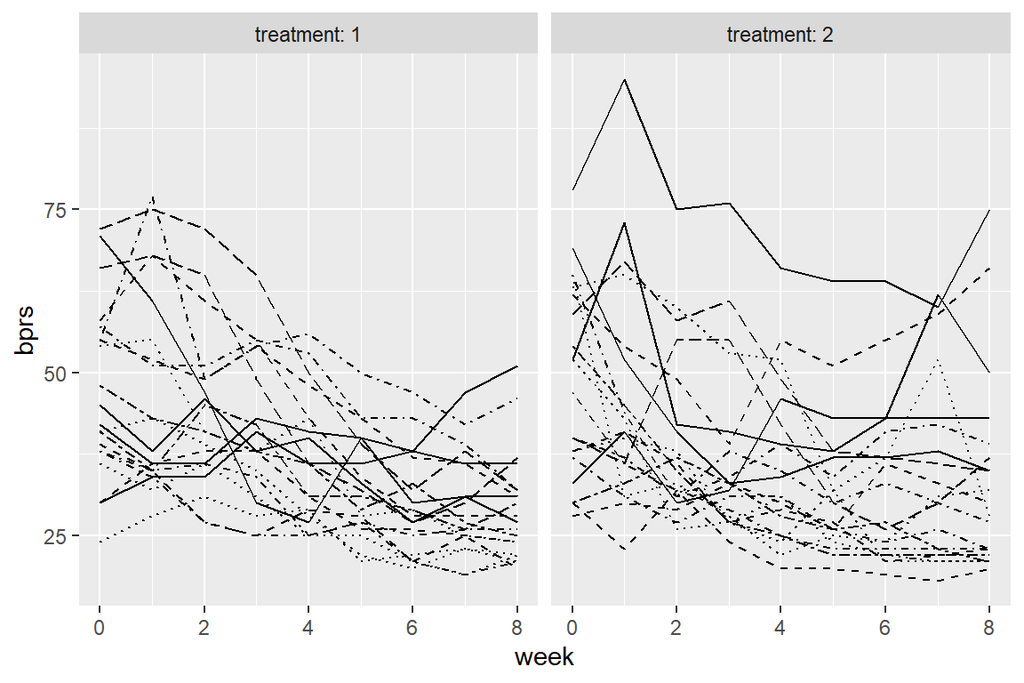

```r
ggplot(bprsl, aes(x = week, y = bprs, linetype = subject)) +
  geom_line() +
  scale_linetype_manual(values = rep(1:10, times=4)) +
  facet_grid(. ~ treatment, labeller = label_both) +
  theme(legend.position = "none") +
  scale_y_continuous(limits = c(min(bprsl$bprs), max(bprsl$bprs)))
```

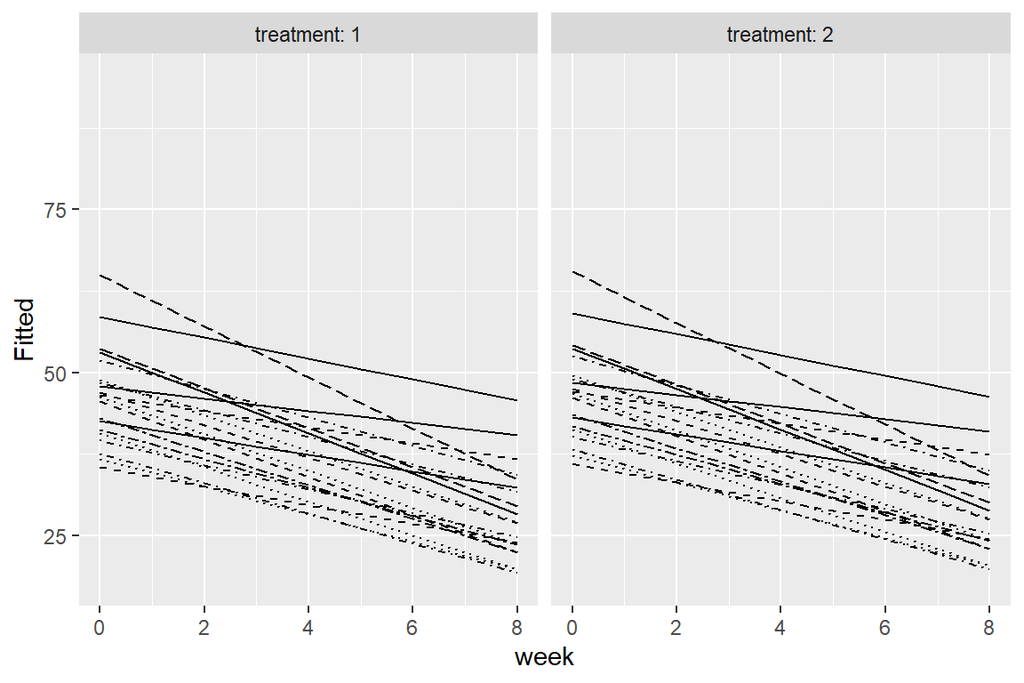

```r
Fitted <- fitted(Model3)

bprsl <- bprsl %>%
  mutate(Fitted)

ggplot(bprsl, aes(x = week, y = Fitted, linetype = subject)) +
  geom_line() +
  scale_linetype_manual(values = rep(1:10, times=4)) +
  facet_grid(. ~ treatment, labeller = label_both) +
  theme(legend.position = "none") +
  scale_y_continuous(limits = c(min(bprsl$bprs), max(bprsl$bprs)))
```

From the graphs with fitted plot graphs (the last ones) we can see that BPRS levels decreases over time. However, it’s hard to identify any differences between the treatment groups. To conclude, looks like both of the treatments manage decrease BPRS levels.